# HeartDiseasePrediction

```python
#to print all the outputs in a cell
from IPython.core.interactiveshell import InteractiveShell
InteractiveShell.ast_node_interactivity = "all"
```

```python
#to ignore warnings
import warnings
warnings.filterwarnings("ignore")
```

```python
import numpy as np # linear algebra
import pandas as pd # data processing, CSV file I/O (e.g. pd.read_csv)
import seaborn as sns
import matplotlib.pyplot as plt
%matplotlib inline
```

```python
df=pd.read_csv('HeartDisease.csv')
```

```python
#from google.colab import drive
#drive.mount('/content/gdrive', force_remount=True)
#import pandas as pd
#df=pd.read_csv('/content/gdrive/MyDrive/ML/Data_Group8.csv')
```

```python
#Set to 2 decimal places, and display all columns
pd.set_option('display.float_format', lambda x: '%.2f' % x)
pd.set_option('display.max_columns', None)
```

### Data Description

```python
df.head()
```

|  | HeartDiseaseorAttack | HighBP | HighChol | CholCheck | BMI | Smoker | Stroke | Diabetes | PhysActivity | Fruits | Veggies | HvyAlcoholConsump | AnyHealthcare | NoDocbcCost | GenHlth | MentHlth | PhysHlth | DiffWalk | Sex | Age | Education | Income |
| --- | --- | --- | --- | --- | --- | --- | --- | --- | --- | --- | --- | --- | --- | --- | --- | --- | --- | --- | --- | --- | --- | --- |
| 0 | 0.00 | 1.00 | 1.00 | 1.00 | 40.00 | 1.00 | 0.00 | 0.00 | 0.00 | 0.00 | 1.00 | 0.00 | 1.00 | 0.00 | 5.00 | 18.00 | 15.00 | 1.00 | 0.00 | 9.00 | 4.00 | 3.00 |
| 1 | 0.00 | 0.00 | 0.00 | 0.00 | 25.00 | 1.00 | 0.00 | 0.00 | 1.00 | 0.00 | 0.00 | 0.00 | 0.00 | 1.00 | 3.00 | 0.00 | 0.00 | 0.00 | 0.00 | 7.00 | 6.00 | 1.00 |
| 2 | 0.00 | 1.00 | 1.00 | 1.00 | 28.00 | 0.00 | 0.00 | 0.00 | 0.00 | 1.00 | 0.00 | 0.00 | 1.00 | 1.00 | 5.00 | 30.00 | 30.00 | 1.00 | 0.00 | 9.00 | 4.00 | 8.00 |
| 3 | 0.00 | 1.00 | 0.00 | 1.00 | 27.00 | 0.00 | 0.00 | 0.00 | 1.00 | 1.00 | 1.00 | 0.00 | 1.00 | 0.00 | 2.00 | 0.00 | 0.00 | 0.00 | 0.00 | 11.00 | 3.00 | 6.00 |
| 4 | 0.00 | 1.00 | 1.00 | 1.00 | 24.00 | 0.00 | 0.00 | 0.00 | 1.00 | 1.00 | 1.00 | 0.00 | 1.00 | 0.00 | 2.00 | 3.00 | 0.00 | 0.00 | 0.00 | 11.00 | 5.00 | 4.00 |

```python
print(df.shape)
```

```
(253680, 22)
```

```python
df.columns.values
```

```
array(['HeartDiseaseorAttack', 'HighBP', 'HighChol', 'CholCheck', 'BMI',
       'Smoker', 'Stroke', 'Diabetes', 'PhysActivity', 'Fruits',
       'Veggies', 'HvyAlcoholConsump', 'AnyHealthcare', 'NoDocbcCost',
       'GenHlth', 'MentHlth', 'PhysHlth', 'DiffWalk', 'Sex', 'Age',
       'Education', 'Income'], dtype=object)
```

```python
df.info()
```

```
<class 'pandas.core.frame.DataFrame'>
RangeIndex: 253680 entries, 0 to 253679
Data columns (total 22 columns):
 #   Column                Non-Null Count   Dtype
---  ------                --------------   -----
 0   HeartDiseaseorAttack  253680 non-null  float64
 1   HighBP                253680 non-null  float64
 2   HighChol              253680 non-null  float64
 3   CholCheck             253680 non-null  float64
 4   BMI                   253680 non-null  float64
 5   Smoker                253680 non-null  float64
 6   Stroke                253680 non-null  float64
 7   Diabetes              253680 non-null  float64
 8   PhysActivity          253680 non-null  float64
 9   Fruits                253680 non-null  float64
 10  Veggies               253680 non-null  float64
 11  HvyAlcoholConsump     253680 non-null  float64
 12  AnyHealthcare         253680 non-null  float64
 13  NoDocbcCost           253680 non-null  float64
 14  GenHlth               253680 non-null  float64
 15  MentHlth              253680 non-null  float64
 16  PhysHlth              253680 non-null  float64
 17  DiffWalk              253680 non-null  float64
 18  Sex                   253680 non-null  float64
 19  Age                   253680 non-null  float64
 20  Education             253680 non-null  float64
 21  Income                253680 non-null  float64
dtypes: float64(22)
memory usage: 42.6 MB
```

Inference:

- Data has only float values
- No variable column has null/missing values

### Data Cleaning

```python
#Renaming Column names
df.rename(columns={'HeartDiseaseorAttack':'HeartDisease'}, inplace=True)
df.rename(columns={'HvyAlcoholConsump':'Alcohol'}, inplace=True)
df.rename(columns={'Smoker':'Smoke'}, inplace=True)
df.rename(columns={'AnyHealthcare':'Healthcare'}, inplace=True)
df.rename(columns={'NoDocbcCost':'DocCost'}, inplace=True)
```

```python
df.info()
```

```
<class 'pandas.core.frame.DataFrame'>
RangeIndex: 253680 entries, 0 to 253679
Data columns (total 22 columns):
 #   Column        Non-Null Count   Dtype
---  ------        --------------   -----
 0   HeartDisease  253680 non-null  float64
 1   HighBP        253680 non-null  float64
 2   HighChol      253680 non-null  float64
 3   CholCheck     253680 non-null  float64
 4   BMI           253680 non-null  float64
 5   Smoke         253680 non-null  float64
 6   Stroke        253680 non-null  float64
 7   Diabetes      253680 non-null  float64
 8   PhysActivity  253680 non-null  float64
 9   Fruits        253680 non-null  float64
 10  Veggies       253680 non-null  float64
 11  Alcohol       253680 non-null  float64
 12  Healthcare    253680 non-null  float64
 13  DocCost       253680 non-null  float64
 14  GenHlth       253680 non-null  float64
 15  MentHlth      253680 non-null  float64
 16  PhysHlth      253680 non-null  float64
 17  DiffWalk      253680 non-null  float64
 18  Sex           253680 non-null  float64
 19  Age           253680 non-null  float64
 20  Education     253680 non-null  float64
 21  Income        253680 non-null  float64
dtypes: float64(22)
memory usage: 42.6 MB
```

```python
df.describe()
```

|  | HeartDisease | HighBP | HighChol | CholCheck | BMI | Smoke | Stroke | Diabetes | PhysActivity | Fruits | Veggies | Alcohol | Healthcare | DocCost | GenHlth | MentHlth | PhysHlth | DiffWalk | Sex | Age | Education | Income |
| --- | --- | --- | --- | --- | --- | --- | --- | --- | --- | --- | --- | --- | --- | --- | --- | --- | --- | --- | --- | --- | --- | --- |
| count | 253680.00 | 253680.00 | 253680.00 | 253680.00 | 253680.00 | 253680.00 | 253680.00 | 253680.00 | 253680.00 | 253680.00 | 253680.00 | 253680.00 | 253680.00 | 253680.00 | 253680.00 | 253680.00 | 253680.00 | 253680.00 | 253680.00 | 253680.00 | 253680.00 | 253680.00 |
| mean | 0.09 | 0.43 | 0.42 | 0.96 | 28.38 | 0.44 | 0.04 | 0.30 | 0.76 | 0.63 | 0.81 | 0.06 | 0.95 | 0.08 | 2.51 | 3.18 | 4.24 | 0.17 | 0.44 | 8.03 | 5.05 | 6.05 |
| std | 0.29 | 0.49 | 0.49 | 0.19 | 6.61 | 0.50 | 0.20 | 0.70 | 0.43 | 0.48 | 0.39 | 0.23 | 0.22 | 0.28 | 1.07 | 7.41 | 8.72 | 0.37 | 0.50 | 3.05 | 0.99 | 2.07 |
| min | 0.00 | 0.00 | 0.00 | 0.00 | 12.00 | 0.00 | 0.00 | 0.00 | 0.00 | 0.00 | 0.00 | 0.00 | 0.00 | 0.00 | 1.00 | 0.00 | 0.00 | 0.00 | 0.00 | 1.00 | 1.00 | 1.00 |
| 25% | 0.00 | 0.00 | 0.00 | 1.00 | 24.00 | 0.00 | 0.00 | 0.00 | 1.00 | 0.00 | 1.00 | 0.00 | 1.00 | 0.00 | 2.00 | 0.00 | 0.00 | 0.00 | 0.00 | 6.00 | 4.00 | 5.00 |
| 50% | 0.00 | 0.00 | 0.00 | 1.00 | 27.00 | 0.00 | 0.00 | 0.00 | 1.00 | 1.00 | 1.00 | 0.00 | 1.00 | 0.00 | 2.00 | 0.00 | 0.00 | 0.00 | 0.00 | 8.00 | 5.00 | 7.00 |
| 75% | 0.00 | 1.00 | 1.00 | 1.00 | 31.00 | 1.00 | 0.00 | 0.00 | 1.00 | 1.00 | 1.00 | 0.00 | 1.00 | 0.00 | 3.00 | 2.00 | 3.00 | 0.00 | 1.00 | 10.00 | 6.00 | 8.00 |
| max | 1.00 | 1.00 | 1.00 | 1.00 | 98.00 | 1.00 | 1.00 | 2.00 | 1.00 | 1.00 | 1.00 | 1.00 | 1.00 | 1.00 | 5.00 | 30.00 | 30.00 | 1.00 | 1.00 | 13.00 | 6.00 | 8.00 |

#### Key Observations:

```python
df.HeartDisease.value_counts()
```

```
0.00    229787
1.00     23893
Name: HeartDisease, dtype: int64
```

This tells us how many people have heart disease/attack and how many do not. Many people have not suffered from heart disease/attack compared to those who have. This shows that the dataset is imbalanced and might give inaccurate predictions.

### Data Analysis

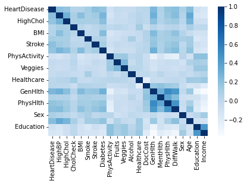

```python
#Checking correlation
plt.figure(figsize=(6,4))
sns.heatmap(df.corr(),cmap='Blues',annot=False)
```

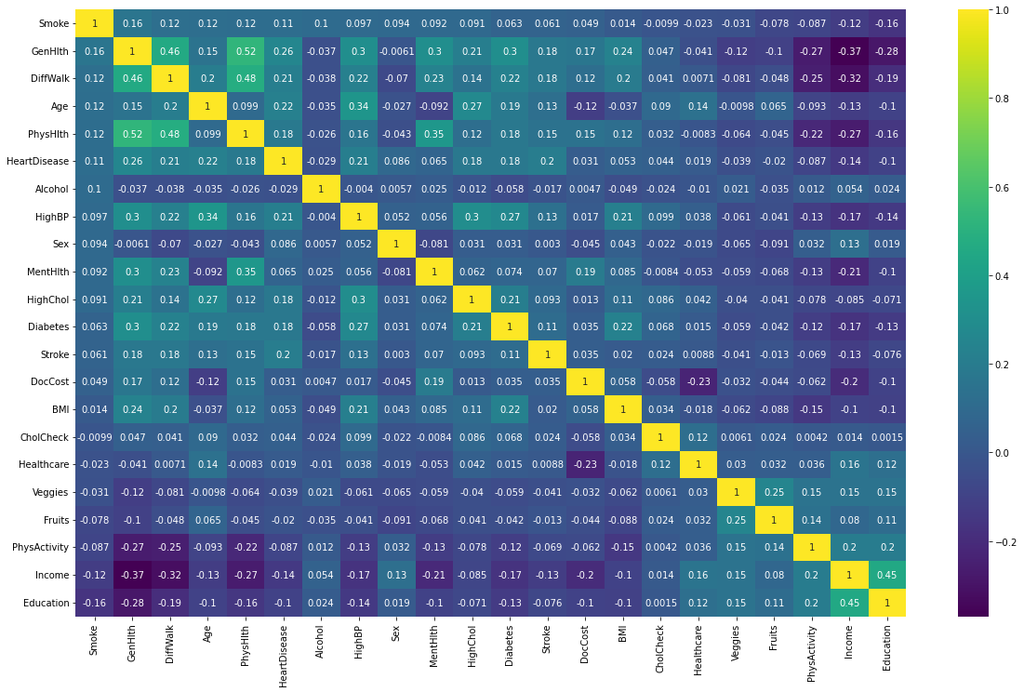

```python
#Quality correlation matrix
k = 22 #number of variables for heatmap
cols = df.corr().nlargest(k, 'Smoke')['Smoke'].index
cm = df[cols].corr()
plt.figure(figsize=(20,12))
sns.heatmap(cm, annot=True, cmap = 'viridis')
```

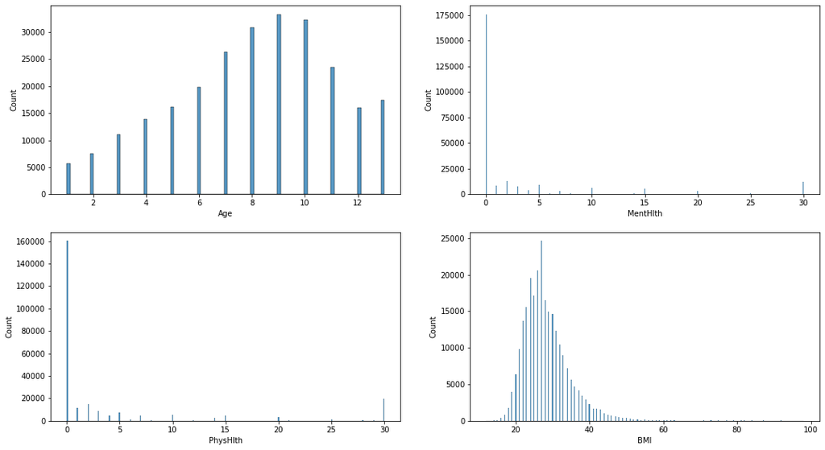

```python
distcol = ['Age', 'MentHlth', 'PhysHlth', 'BMI']
fig, axes = plt.subplots(2, 2, figsize=(18, 10))
sns.histplot(ax=axes[0,0], data=df, x=distcol[0])
sns.histplot(ax=axes[0,1], data=df, x=distcol[1])
sns.histplot(ax=axes[1,0], data=df, x=distcol[2])
sns.histplot(ax=axes[1,1], data=df, x=distcol[3])
```

[figure not shown]

```python
target="HeartDisease"

fig, axes = plt.subplots(nrows=df.shape[1], ncols=1, figsize=(10,6*df.shape[1]))
for i in range(len(df.columns)):
    col = df.columns[i]
    sns.countplot(x=col, data=df, hue=target, palette="seismic", ax=axes[i])
axes[0].legend([])
plt.show()
```

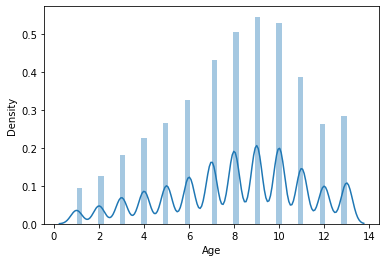

```python
sns.distplot(df.Age)
```

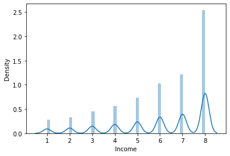

```python
sns.distplot(df.Income)
```

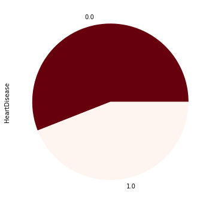

```python
df.groupby('Sex')['HeartDisease'].count().plot(kind='pie',figsize=(10,6),cmap="Reds_r")
```

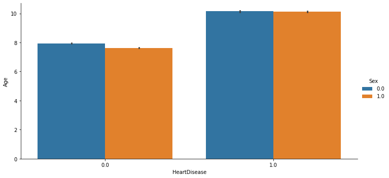

```python
sns.catplot(x='HeartDisease', y='Age', hue='Sex', data=df, kind='bar',aspect=2)
```

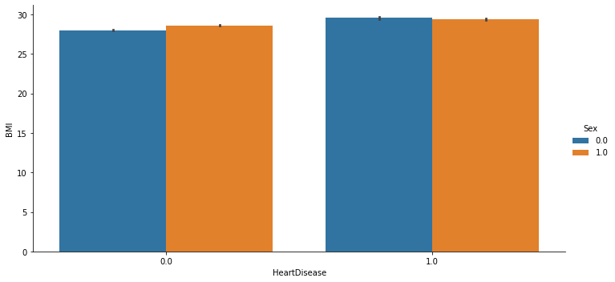

```python
sns.catplot(x='HeartDisease', y='BMI', hue='Sex', data=df, kind='bar',aspect=2)
```

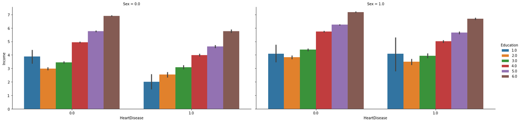

```python
sns.catplot(x='HeartDisease',y='Income',hue='Education',col='Sex',\
               data=df,kind='bar',aspect=2)
```

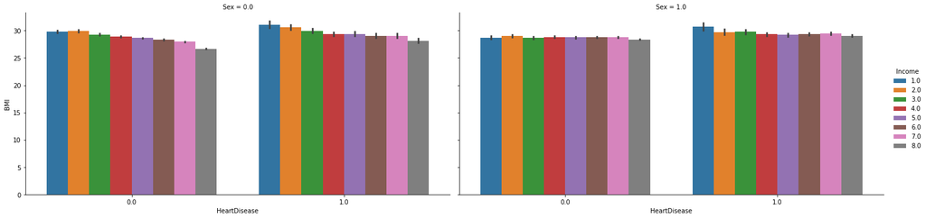

```python
sns.catplot(x='HeartDisease',y='BMI',hue='Income',col='Sex',\
               data=df,kind='bar',aspect=2)
```

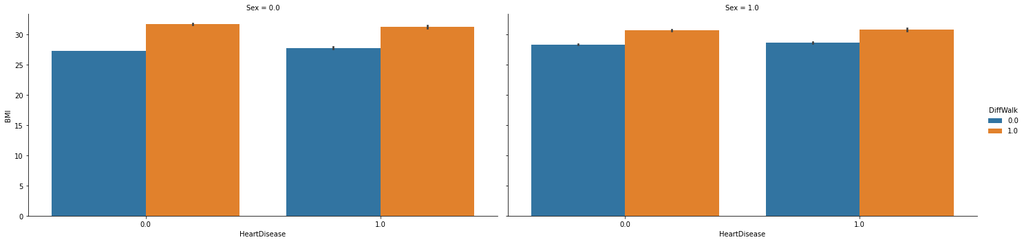

```python
sns.catplot(x='HeartDisease',y='BMI',hue='DiffWalk',col='Sex',\
               data=df,kind='bar',aspect=2)
```

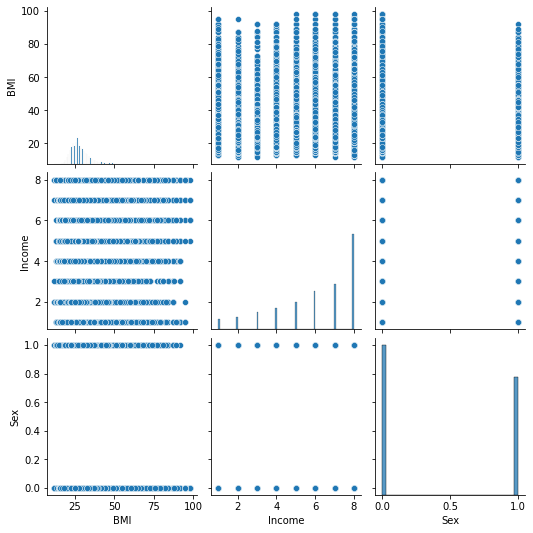

```python
sns.pairplot(df[['BMI','Income','Sex']])
```

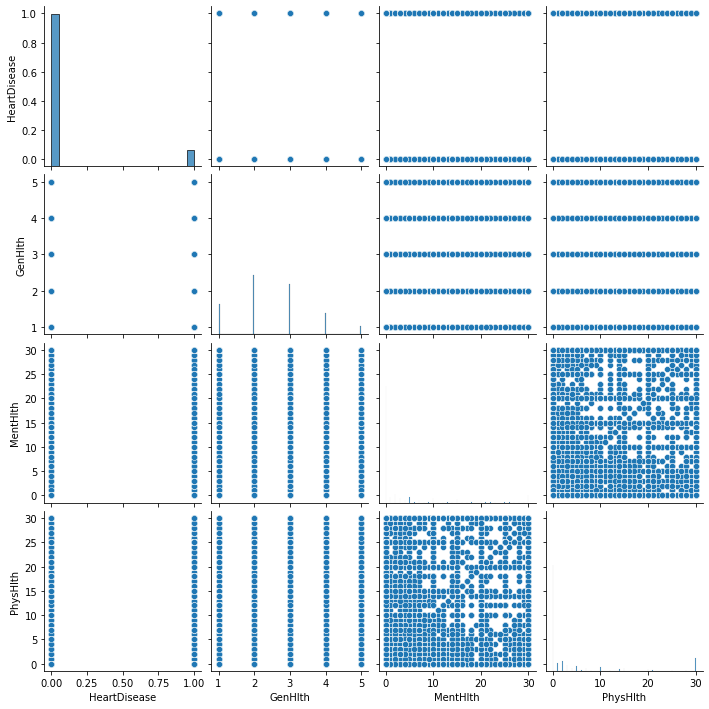

```python
sns.pairplot(df[['HeartDisease','GenHlth','MentHlth','PhysHlth']])
```

### Feature Engineering : Part1

```python
## See which cols are continuous variables and which are categorical cariables
for col in df.columns:
    print('{} : {}' .format(col, df[col].unique()))
```

```
HeartDisease : [0. 1.]
HighBP : [1. 0.]
HighChol : [1. 0.]
CholCheck : [1. 0.]
BMI : [40. 25. 28. 27. 24. 30. 34. 26. 33. 21. 23. 22. 38. 32. 37. 31. 29. 20.
 35. 45. 39. 19. 47. 18. 36. 43. 55. 49. 42. 17. 16. 41. 44. 50. 59. 48.
 52. 46. 54. 57. 53. 14. 15. 51. 58. 63. 61. 56. 74. 62. 64. 66. 73. 85.
 60. 67. 65. 70. 82. 79. 92. 68. 72. 88. 96. 13. 81. 71. 75. 12. 77. 69.
 76. 87. 89. 84. 95. 98. 91. 86. 83. 80. 90. 78.]
Smoke : [1. 0.]
Stroke : [0. 1.]
Diabetes : [0. 2. 1.]
PhysActivity : [0. 1.]
Fruits : [0. 1.]
Veggies : [1. 0.]
Alcohol : [0. 1.]
Healthcare : [1. 0.]
DocCost : [0. 1.]
GenHlth : [5. 3. 2. 4. 1.]
MentHlth : [18.  0. 30.  3.  5. 15. 10.  6. 20.  2. 25.  1.  4.  7.  8. 21. 14. 26.
 29. 16. 28. 11. 12. 24. 17. 13. 27. 19. 22.  9. 23.]
PhysHlth : [15.  0. 30.  2. 14. 28.  7. 20.  3. 10.  1.  5. 17.  4. 19.  6. 12. 25.
 27. 21. 22.  8. 29. 24.  9. 16. 18. 23. 13. 26. 11.]
DiffWalk : [1. 0.]
Sex : [0. 1.]
Age : [ 9.  7. 11. 10.  8. 13.  4.  6.  2. 12.  5.  1.  3.]
Education : [4. 6. 3. 5. 2. 1.]
Income : [3. 1. 8. 6. 4. 7. 2. 5.]
```

```python
for col in df.columns:
    if(len(df[col].unique()) > 2):
        print('{} Length: {}'.format(col, len(df[col].unique())))
        print('{} : {}' .format(col, np.sort(df[col].unique())))
```

```
BMI Length: 84
BMI : [12. 13. 14. 15. 16. 17. 18. 19. 20. 21. 22. 23. 24. 25. 26. 27. 28. 29.
 30. 31. 32. 33. 34. 35. 36. 37. 38. 39. 40. 41. 42. 43. 44. 45. 46. 47.
 48. 49. 50. 51. 52. 53. 54. 55. 56. 57. 58. 59. 60. 61. 62. 63. 64. 65.
 66. 67. 68. 69. 70. 71. 72. 73. 74. 75. 76. 77. 78. 79. 80. 81. 82. 83.
 84. 85. 86. 87. 88. 89. 90. 91. 92. 95. 96. 98.]
Diabetes Length: 3
Diabetes : [0. 1. 2.]
GenHlth Length: 5
GenHlth : [1. 2. 3. 4. 5.]
MentHlth Length: 31
MentHlth : [ 0.  1.  2.  3.  4.  5.  6.  7.  8.  9. 10. 11. 12. 13. 14. 15. 16. 17.
 18. 19. 20. 21. 22. 23. 24. 25. 26. 27. 28. 29. 30.]
PhysHlth Length: 31
PhysHlth : [ 0.  1.  2.  3.  4.  5.  6.  7.  8.  9. 10. 11. 12. 13. 14. 15. 16. 17.
 18. 19. 20. 21. 22. 23. 24. 25. 26. 27. 28. 29. 30.]
Age Length: 13
Age : [ 1.  2.  3.  4.  5.  6.  7.  8.  9. 10. 11. 12. 13.]
Education Length: 6
Education : [1. 2. 3. 4. 5. 6.]
Income Length: 8
Income : [1. 2. 3. 4. 5. 6. 7. 8.]
```

```python
df = df.astype(np.int8)
df.info()
```

```
<class 'pandas.core.frame.DataFrame'>
RangeIndex: 253680 entries, 0 to 253679
Data columns (total 22 columns):
 #   Column        Non-Null Count   Dtype
---  ------        --------------   -----
 0   HeartDisease  253680 non-null  int8
 1   HighBP        253680 non-null  int8
 2   HighChol      253680 non-null  int8
 3   CholCheck     253680 non-null  int8
 4   BMI           253680 non-null  int8
 5   Smoke         253680 non-null  int8
 6   Stroke        253680 non-null  int8
 7   Diabetes      253680 non-null  int8
 8   PhysActivity  253680 non-null  int8
 9   Fruits        253680 non-null  int8
 10  Veggies       253680 non-null  int8
 11  Alcohol       253680 non-null  int8
 12  Healthcare    253680 non-null  int8
 13  DocCost       253680 non-null  int8
 14  GenHlth       253680 non-null  int8
 15  MentHlth      253680 non-null  int8
 16  PhysHlth      253680 non-null  int8
 17  DiffWalk      253680 non-null  int8
 18  Sex           253680 non-null  int8
 19  Age           253680 non-null  int8
 20  Education     253680 non-null  int8
 21  Income        253680 non-null  int8
dtypes: int8(22)
memory usage: 5.3 MB
```

- There are no feature whose data type is object
- All features' data type are int
- Some of the features can be ordinal while some of them must be encoded as they are categorical features

#### Feature Description

- Categorical Features:
  - *HighBP* Whether the invidual has High BP or not
  - *HighChol* Whether the invidual has High Cholesterol or not
  - *CholCheck* Whether the invidual has got Choleterol levels checked or not
  - *Smoke* Whether the individual smokes or not
  - *Stroke* Whether the individual has ever had a heart stroke or not
  - *Diabetes* Whether the individual has diabetes or not
  - *PhysActivity* Whether the individual is physically active or not
  - *Fruits* Whether the individual consumes fruits or not
  - *Veggies* Whether the individual consumes vegetables or not
  - *Alcohol* Whether the individual consumes alcohol or not
  - *Healthcare* Whether the individual has any healthcare plan or not
  - *DocCost* Whether the individual has incurred any expenses for doctor visit or not
  - *DiffWalk* Whether the individual faces any difficulty in walking or not
- Ordinal Features:
  - *Sex* Sex of the individual
  - *Age* Age of the individual
  - *Education* Educational qualification of the individual
  - *Income* Income of the individual
  - *GenHlth* Rating of the individual's General Health
  - *MentHlth* Rating of the individual's Mental Health
  - *PhysHlth* Rating of the individual's Physical Health
- Continuous Features:
  - *BMI* BMI level of the individual

#### Target Variable Description

- *HeartDisease* Whether the indvidual has suffered from heart disease/attack or not

[figure not shown]

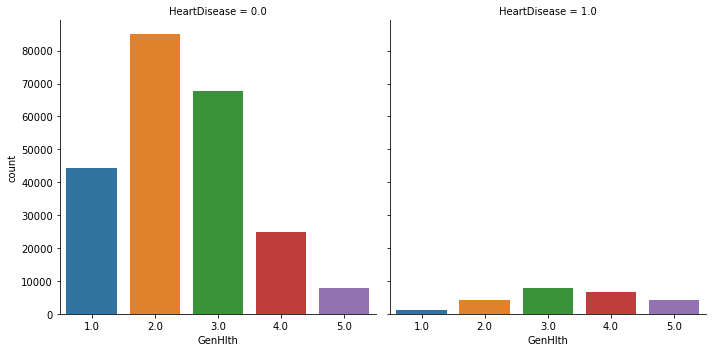

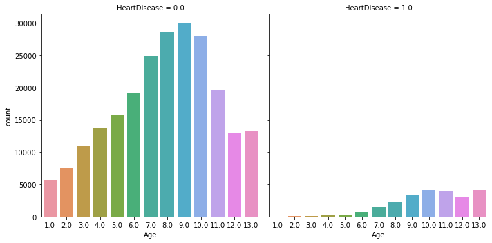

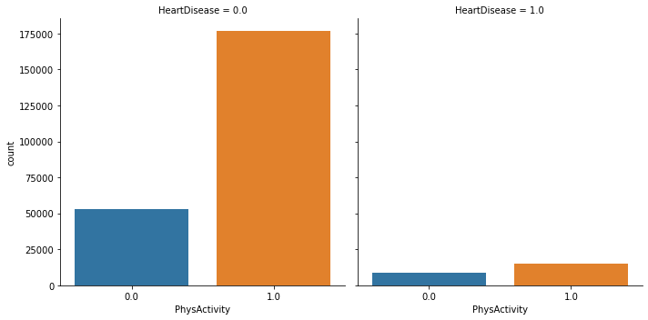

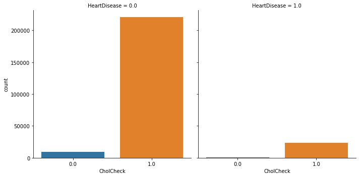

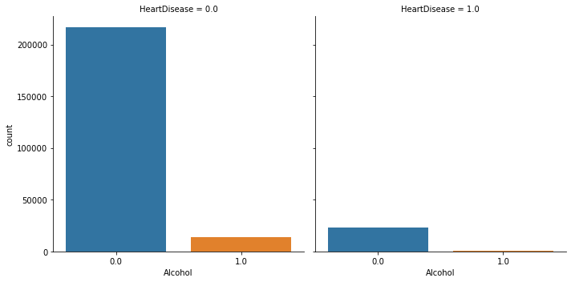

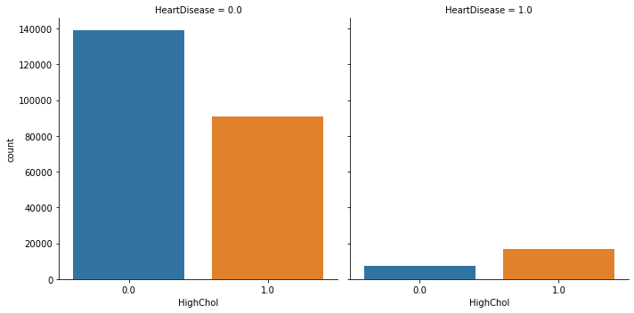

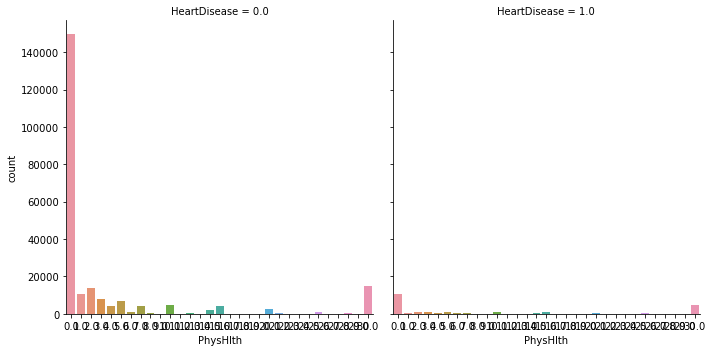

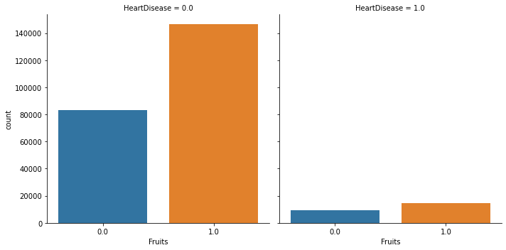

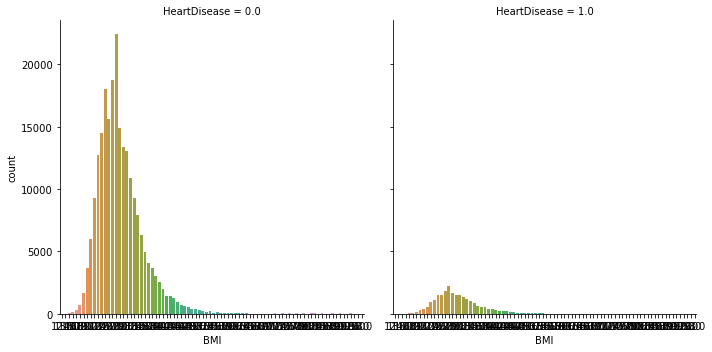

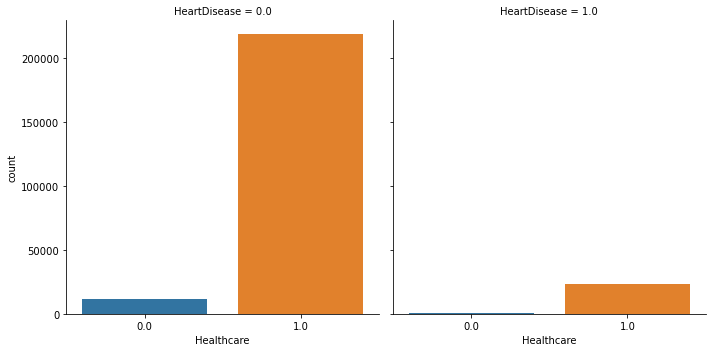

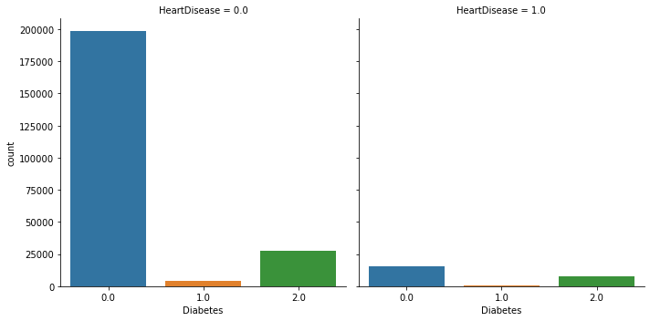

[10 more figures not shown]

```python
## Features' distriubtion with different labels
cols = list(set(df.columns) - set(['HeartDisease']))
cols = np.array(cols).reshape(3, 7)
fig, axes = plt.subplots(3, 7)

for x in range(cols.shape[0]):
    for y in range(cols.shape[1]):
        sns.catplot(x = cols[x, y], kind = 'count', col='HeartDisease', data =df, ax=axes[x,y])
```

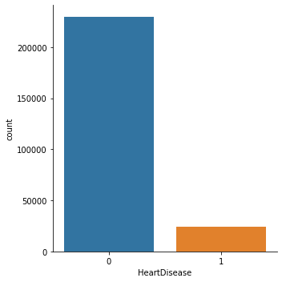

```python
sns.catplot(data=df, x='HeartDisease', kind='count')
```

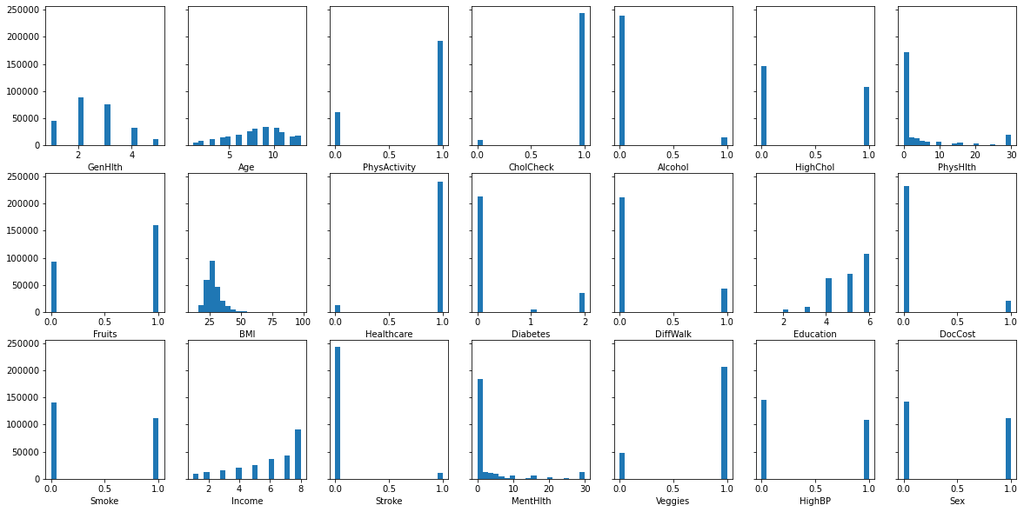

```python
## Features distribution
cols = list(set(df.columns) - set(['HeartDisease']))
cols = np.array(cols).reshape(3, 7)
fig, axes = plt.subplots(3, 7, figsize=(20, 10), sharey=True)

for x in range(cols.shape[0]):
    for y in range(cols.shape[1]):
        axes[x,y].hist(df[cols[x,y]], bins=20)
        #axes[x,y].plot(df[cols[x,y]], color='red')
        axes[x,y].set_xlabel('{}'.format(cols[x,y]))
```

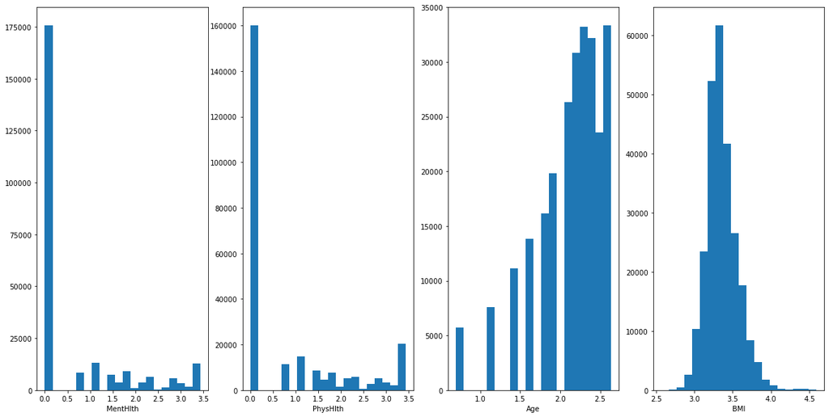

```python
#Using log to change the distribution
log_features = ['MentHlth', 'PhysHlth', 'Age', 'BMI']
fig, axes = plt.subplots(1, len(log_features), figsize=(20, 10))
for i, fet in zip(range(len(log_features)), log_features):
    axes[i].hist(x = np.log(df[fet]+1), bins=20)
    axes[i].set_xlabel('{}'.format(fet))
```

### Dimensionality reduction : Visualizing data in lower dimension

#### 1.TSNE

```python
from sklearn.manifold import TSNE
from sklearn.preprocessing import StandardScaler

X = df.drop(columns=['HeartDisease']).to_numpy()
X_trans = StandardScaler().fit_transform(X)
X_embedded = TSNE(n_components=2, learning_rate=500).fit_transform(X_trans)
X_embedded.shape
```

```
(253680, 2)
```

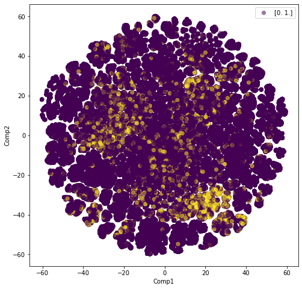

```python
merged = np.concatenate((X_embedded, np.array(df['HeartDisease'])[:, np.newaxis]), axis=1)
plt.figure(figsize=(8,8))
plt.scatter(x = merged[:, 0], y = merged[:, 1], c=merged[:, 2], alpha=0.5, label=np.unique(merged[:,2]))
plt.xlabel('Comp1')
plt.ylabel('Comp2')
plt.legend()
```

#### 2.PCA

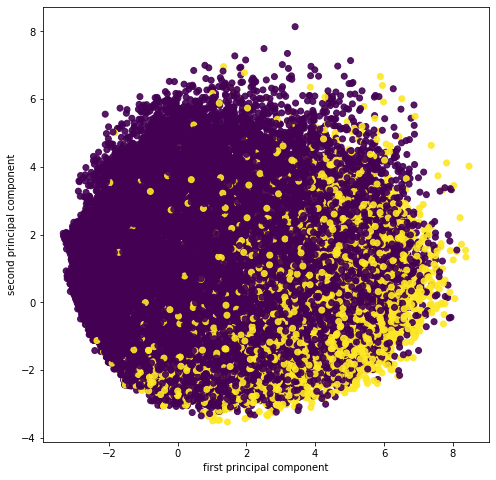

```python
from sklearn.decomposition import PCA
X = df.drop(columns=['HeartDisease']).to_numpy()
X_trans = StandardScaler().fit_transform(X)
pca = PCA(n_components=2)
pca.fit(X_trans)
X_pca_scaled = pca.transform(X_trans)
plt.figure(figsize=(8,8))
plt.scatter(X_pca_scaled[:, 0], X_pca_scaled[:, 1], c=np.array(df['HeartDisease']), alpha=.9)
plt.xlabel("first principal component")
plt.ylabel("second principal component")
```

#### 3.UMAP

```python
import umap

reducer = umap.UMAP()
X = df.drop(columns=['HeartDisease']).to_numpy()
X_trans = StandardScaler().fit_transform(X)

embedding = reducer.fit_transform(X_trans)
embedding.shape
```

```
(253680, 2)
```

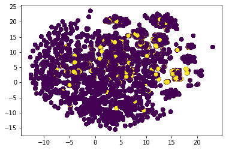

```python
plt.scatter(
embedding[:,0], embedding[:,1],
c = df['HeartDisease'].values)
```

```python
percent_1 = df['HeartDisease'].values.sum()/ len(df['HeartDisease'].values)
percent_0 = 1-percent_1
print('Label 0 take {:.2f} percent' .format(percent_0*100))
print('Label 1 take {:.2f} percent' .format(percent_1*100))
```

```
Label 0 take 90.58 percent
Label 1 take 9.42 percent
```

### Feature Engineering : Part2

```python
df.info()
```

[output not shown]

```python
target = 'HeartDisease'
ordinal_features = ['Education', 'Age', 'PhysHlth', 'MentHlth','GenHlth','Income']
categorical_features = ['Sex', 'HighBP', 'HighChol', 'CholCheck', 'Smoke', 'Stroke', 'PhysActivity', 'Fruits', 'Veggies', 'Diabetes', 'Alcohol', 'Healthcare', 'DocCost', 'DiffWalk']
continuous_features = ['BMI']
health = ['PhysActivity', 'Fruits', 'Veggies', 'DocCost']
unhealth = ['HighBP', 'HighChol', 'CholCheck', 'Smoke', 'Stroke', 'Diabetes', 'Alcohol', 'Healthcare']
```

```python
inter = health + unhealth
```

### Classification Models

```python
from sklearn import metrics
from sklearn.model_selection import train_test_split, GridSearchCV, cross_validate
from sklearn.pipeline import make_pipeline, Pipeline
from sklearn.preprocessing import MinMaxScaler, StandardScaler, OneHotEncoder
from sklearn.linear_model import LogisticRegression
from sklearn.svm import LinearSVC
from sklearn.neighbors import KNeighborsClassifier
from sklearn.compose import make_column_transformer
from sklearn.impute import SimpleImputer
from sklearn.metrics import recall_score, confusion_matrix, precision_score, f1_score, accuracy_score, classification_report
import lightgbm as lgb
```

#### Preprocessing

- Splitting the original data into train-validate set (90%) and test set (10%) using random state = 0.
- Then, split the train-validate set into training set (80%) and validation set (20%) using random state = 0.
- Splitting out into categorical and numerical features, to preprocess them differently.
- For scikit-learn's implementation, it requires numerical values for it's data matrix. This means all categorical variables needs to be turned into binary features via one-hot encoding.

```python
df
```

[output not shown]

253680 rows × 22 columns

```python
## Split data into train_val and test
from sklearn.model_selection import train_test_split

df_ml = df.copy()
X1 = df_ml.drop(columns = ['HeartDisease'])
y1 = df_ml.HeartDisease

X_trainval1, X_test1, y_trainval1, y_test1 = train_test_split(X1, y1, test_size = 0.1, stratify = y1, random_state = 0)
X_train1, X_val1, y_train1, y_val1 = train_test_split(X_trainval1, y_trainval1, stratify = y_trainval1, test_size = 0.2, random_state = 0)

train_val = pd.concat([X_trainval1, y_trainval1], axis=1)

X_train_val = X_trainval1
y_train_val = y_trainval1
X_train, X_val, y_train, y_val = X_train1, X_val1, y_train1, y_val1
X_test = X_test1
y_test = y_test1

## Get balanced data
from numpy.random import MT19937
from numpy.random import RandomState, SeedSequence
def under_sample(label, target):
    rand_state = RandomState(MT19937(SeedSequence(123456789)))
    target_usamp = target[target == label]
    target_osamp = target[target != label]
    resampled_idx = rand_state.choice(target_osamp.index, size=len(target_usamp))

    return resampled_idx

rsp_idx = under_sample(1, y_train_val)
data_balanced_0 = train_val.loc[rsp_idx, :]
data_label_1 = train_val[y_trainval1 == 1]
print(data_balanced_0.shape, data_label_1.shape)
balanced_data = pd.concat([data_balanced_0, data_label_1], axis=0)
```

```
(21504, 22) (21504, 22)
```

```python
from sklearn.model_selection import StratifiedKFold
#target encoding
def target_enc(df, cols, target):
    X, y = df[cols], df[target]
    skf = StratifiedKFold(n_splits=5, shuffle=True)
    target_mean_features = []
    for col in cols:
        colname = col + '_target_mean'
        target_mean_features.append(colname)
        df[colname] = 0
    for tr_idx, val_idx in skf.split(X,y):
        X_train, X_val = df.iloc[tr_idx], df.iloc[val_idx]
        for col in cols:
            mean = X_train.groupby(by=col)[target].mean()
            df[col+'_target_mean'].iloc[val_idx] = X_val[col].map(mean)
    prior = df[target].mean()
    df[target_mean_features].fillna(prior, inplace=True)


    #regularization on target encoding

    for feature in target_mean_features:
        df[feature] = df[feature] * len(df) + df[feature].nunique() * prior
        df[feature] = df[feature] / (len(df) + df[feature].nunique())
    return df[target_mean_features]

def prepare_train(train, target):
    train['sumHealth'] = train[health].sum(axis=1)
    train['sumUnhealth'] = train[unhealth].sum(axis=1)
    train['diff_health'] = train['sumHealth'] - train['sumUnhealth']

    ## Label encoding and interactive labels
    features_mean_enc = categorical_features
    mean_enc_cat = target_enc(train[categorical_features+[target]], categorical_features, target)
    #mean_enc_ord = target_enc(train[ordinal_features + [target]], ordinal_features, target)

    train = pd.concat([train.drop(columns=features_mean_enc), mean_enc_cat], axis=1)

    for i in inter:
      for j in inter:
        if i!=j:
          train[i+'|'+j] = train[i+'_target_mean'] * train[j+'_target_mean']


    return train


def prepare_test(test, train, target):
    test['sumHealth'] = test[health].sum(axis=1)
    test['sumUnhealth'] = test[unhealth].sum(axis=1)
    test['diff_health'] = test['sumHealth'] - test['sumUnhealth']

    features_to_enc = categorical_features
    for feature in features_to_enc:
        test[feature + '_target_mean'] = test[feature].map(train.groupby(by=feature)[target].mean())

    prior = train[target].mean()
    test[features_to_enc].fillna(prior, inplace=True)

    #Smooth
    for feature in features_to_enc:
        test[feature] = test[feature] * len(test) + test[feature].nunique() * prior
        test[feature] = test[feature] / (len(test) + test[feature].nunique())

    for i in inter:
      for j in inter:
        if i!=j:
          test[i+'|'+j] = test[i+'_target_mean'] * test[j+'_target_mean']

    test = test.drop(columns=features_to_enc)
    return test

def prepare(train_val, X_test, y_test, target):
    train = prepare_train(train_val, target)
    X_train, X_val, y_train, y_val = train_test_split(train.drop(columns=[target]), train[target], test_size=0.1)
    test = pd.concat([X_test, y_test], axis=1)
    test_set = prepare_test(test, train_val, target)
    X_test_ = test_set.drop(columns=[target])
    y_test_ = test_set[target]


    return X_train, X_val, y_train, y_val, X_test_, y_test_
```

```python
## Balanced raw data
X_balanced_raw = balanced_data.drop(columns=[target])
y_balanced_raw = balanced_data[target]
```

```python
## Balanced data
X_train_, X_val_, y_train_, y_val_, X_test_, y_test_ = prepare(balanced_data, X_test, y_test, target)
```

```python
## Unbalanced data
X_train_u, X_val_u, y_train_u, y_val_u, X_test_u, y_test_u = prepare(train_val, X_test, y_test, target)
```